# Model building with latent variables: Markov models for animal movement

Author

Vianey Leos Barajas

Published

2025-12-14

Modified

2026-06-15

This notebook includes the code for Bayesian Workflow book Chapter 26 *Model building with latent variables: Markov models for animal movement*.

# 1 Introduction

To demonstrate how hidden Markov models (HMMs) are used to model animal movement, we use positional data analyzed by Towner et al. (2016). Here we replicate the model building workflow and demonstrate how this would be done in a Bayesian framework.

**Load packages**

```r
library(rprojroot)
root <- has_file(".Bayesian-Workflow-root")$make_fix_file()
library(tidyverse)
library(CircStats)
library(patchwork)
library(lubridate)
library(moveHMM)
library(bayesplot)
library(tidyr)
library(cmdstanr)
options(mc.cores = 4)
# CmdStanR output directory makes Quarto cache to work
dir.create(root("sharks", "stan_output"), showWarnings = FALSE)
options(cmdstanr_output_dir = root("sharks", "stan_output"))
```

# 2 Shark movement data

The positions, in longitude and latitude, of multiple sharks were taken over time in Gansbaii, South Africa. Some sharks have repeated trackings. Hidden Markov models (HMMs) applied to the positions of animals over time are often first transformed into step lengths and turning angles, and then analyzed. Here we use the R package `moveHMM` to process our tracks. `moveHMM` requires a column named ID to denote individual tracks, with multiple IDs possibly corresponding to the same shark if they are tracked multiple times. Because these are discrete-time HMMs, `moveHMM` also assumes that the observations are taken regularly over time, with missing values filling any times where observations were not available. It will not check this automatically, so it is important for users to prepare their data appropriately. In the following code we import the data, use the function `prepData` to compute step lengths and turning angles. We also compute covariates, such as time of day, sex, and chum that will be used for model extensions.

```r
load(root("sharks/data","whiteshark_trackdata.RData"))
sharks.HMMtracks.df$ID <- sharks.HMMtracks.df$SharksexTrackNo
moveHMM_wsdata <- prepData(sharks.HMMtracks.df[, c("ID", "Long", "Lat")], type = c("LL"), coordNames = c("Long", "Lat"))
sharks.HMMtracks.df$steplength <- moveHMM_wsdata$step
sharks.HMMtracks.df$turnang <- moveHMM_wsdata$angle
ws_HMM_full <- sharks.HMMtracks.df |>
  filter(!SharksexTrackNo %in% c("WSF9 T4", "WSF9 T3 B "))
ws_HMM <- ws_HMM_full[, c("dateTime",
                          "SharkName",
                          "SharksexTrackNo",
                          "steplength",
                          "turnang",
                          "year",
                          "month",
                          "CDB")]
```

For implementation in Stan, we must set the NA’s to numeric values, ideally something non-plausible that can be checked in a for loop during likelihood evaluation.

```r
ws_HMM$steplength[is.na(ws_HMM$steplength)] <- -100
ws_HMM$steplength[which(ws_HMM$steplength > 1.5)] <- -100
ws_HMM$turnang[is.na(ws_HMM$turnang)] <- -100
```

We plot two tracks of white shark female 1 that exhibit the distinct movement patterns we are hoping to capture with our HMM:

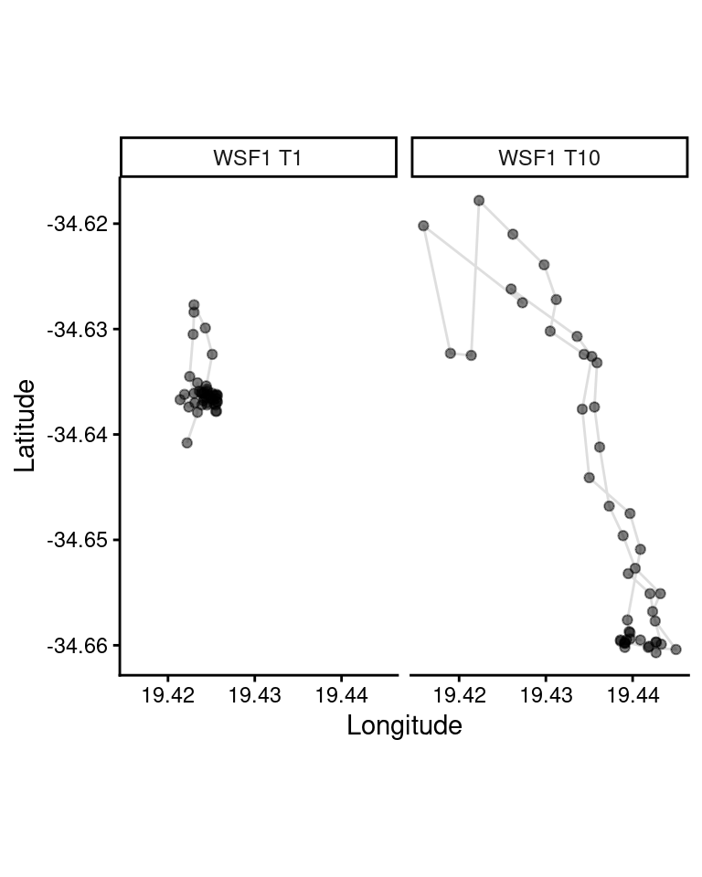

Figure 1

```r
ggplot(data = sharks.HMMtracks.df |>
         dplyr::filter(SharksexTrackNo ==
                         c("WSF1 T1", "WSF1 T10")),
       aes(Long, Lat)) +
  geom_path(aes(group = SharksexTrackNo), alpha = 0.5, color = "grey") +
  geom_point(alpha = 0.5) +
  facet_wrap(~SharksexTrackNo) + theme_classic() +
  ylab("Latitude") + xlab("Longitude") + coord_map()
```

# 3 Initial values for an N-state HMM:

We create two functions to provide starting values for the mean of the state-dependent distribution for step length. Without specifying starting values, the MCMC may have some trouble initializing at plausible values. There may still be issues with initialization depending on starting values for other parameters but for now we proceed only specifying starting values for the means.

```r
init_fun_mu <- function(no_states, no_chains) {
  mu_init <- list()
  for (n in 1:no_chains) {
    mu_init[[n]] <- list(mu = sort(runif(no_states, min = 0, max = 0.5)))
  }
  mu_init
}
init_fun_logmu <- function(no_states, no_chains) {
  log_mu_init <- list()
  for (n in 1:no_chains) {
    log_mu_init[[n]] <- list(log_mu = log(sort(runif(no_states, min = 0, max = 0.5))))
  }
  log_mu_init
}
```

# 4 2-state HMM

We fit a 2-state HMM to the white shark tracks, assuming that each track is an independent realization of the same 2-state HMM. Note that in the corresponding chapter, we modify either the prior distributions for the state-dependent distribution or specify an ordering on the means for the step length state-dependent distribution. The Stan code in `step_turn_hmm.stan` can be modified to mimic different behavior and reproduce similar results.

```r
stanHMM_2states <-  list(
  Nstates = 2,
  Tlen = dim(ws_HMM)[1],
  track_index = as.numeric(as.factor(ws_HMM$SharksexTrackNo)),
  steplength = ws_HMM$steplength,
  angle = ws_HMM$turnang,
  Ntracks = length(unique(ws_HMM$SharksexTrackNo))
)
```

```r
model_2stateHMM <- cmdstan_model(
  root("sharks", "step_turn_hmm.stan")
)
fit_2stateHMM <- model_2stateHMM$sample(
  data = stanHMM_2states,
  init = init_fun_mu(2,4),
  chains = 4
)

fit_2stateHMM$summary(variables = c("mu", "sigma", "mixp",
                                    "xangle", "yangle",
                                    "tpm", "initial_dist",
                                    "lp__"))
```

[output not shown]

Plot MCMC marginal distributions for certain parameters:

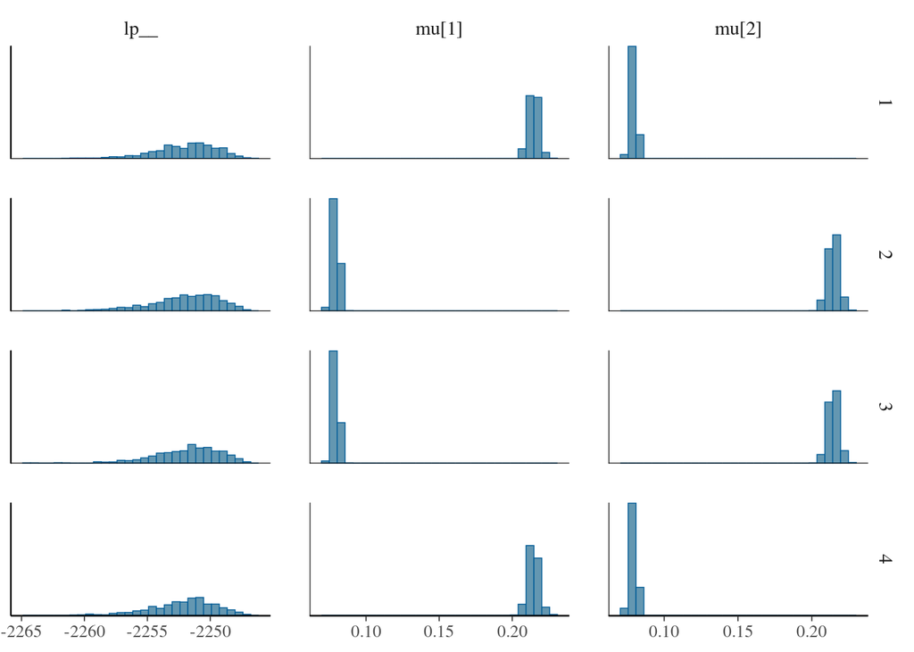

Figure 2

```r
fit_2stateHMM_draws <- fit_2stateHMM$draws(format = "df",
                                           variables = c("mu", "sigma", "mixp",
                                                         "shape", "rate",
                                                         "xangle", "yangle",
                                                         "kappa", "loc",
                                                         "tpm", "initial_dist",
                                                         "lp__"))
mcmc_hist_by_chain(fit_2stateHMM_draws, regex_pars = "mu", pars = "lp__")
```

Plot state-dependent distributions for step length and turning angle:

```r
cbPalette <- c("#999999", "#E69F00", "#56B4E9", "#009E73",
               "#F0E442", "#0072B2", "#D55E00", "#CC79A7")
eval_gamma_sdd <- function(post_draws, no_samples) {
  # setup
  xval <- seq(0.001, 1, len = 200)
  state1_dens <- matrix(NA, nrow = 200, ncol = no_samples)
  state2_dens <- matrix(NA, nrow = 200, ncol = no_samples)

  for (j in 1:no_samples) {
    state1_dens[,j] <- dgamma(xval,
                              shape = as.numeric(post_draws[j, "shape[1]"]),
                              rate = as.numeric(post_draws[j, "rate[1]"]))
    state2_dens[,j] <- dgamma(xval,
                              shape = as.numeric(post_draws[j, "shape[2]"]),
                              rate = as.numeric(post_draws[j, "rate[2]"]))
  }
  sdd <- data.frame(xval = rep(xval, times = no_samples),
                    state1_dens = c(state1_dens),
                    state2_dens = c(state2_dens),
                    sample = rep(1:no_samples, each= 200))
  sdd
}
eval_vonMises_sdd <- function(post_draws, no_samples) {
  # setup
  xval <- seq(-pi, pi, len = 200)
  state1_dens <- matrix(NA, nrow = 200, ncol = no_samples)
  state2_dens <- matrix(NA, nrow = 200, ncol = no_samples)

  for (j in 1:no_samples) {
    state1_dens[,j] <- dvm(xval,
                           mu = as.numeric(post_draws[j, "loc[1]"]),
                           kappa = as.numeric(post_draws[j, "kappa[1]"]))
    state2_dens[,j] <- dvm(xval,
                           mu =  as.numeric(post_draws[j, "loc[2]"]),
                           kappa = as.numeric(post_draws[j, "kappa[2]"]))
  }
  sdd <- data.frame(xval = rep(xval, times = no_samples),
                    state1_dens = c(state1_dens),
                    state2_dens = c(state2_dens),
                    sample = rep(1:no_samples, each= 200))
  sdd
}
sdd_steplength <- eval_gamma_sdd(fit_2stateHMM_draws, no_samples = 1000)
sdd_angle <- eval_vonMises_sdd(fit_2stateHMM_draws, no_samples = 1000)
```

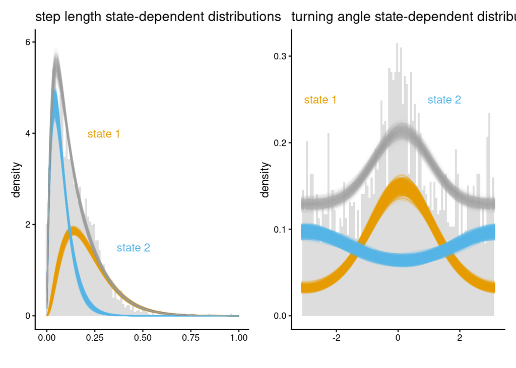

Figure 3

```r
sl_sdd <- ggplot(ws_HMM) +
  geom_histogram(aes(steplength, y = after_stat(density)), bins = 100, alpha = 0.2) +
  xlim(-0.01, 1) +
  geom_line(data = sdd_steplength, aes(xval, 0.5 * state1_dens, group = sample),
            color = cbPalette[2], alpha = 0.2) +
  geom_line(data = sdd_steplength, aes(xval, 0.5 * state2_dens, group = sample),
            color = cbPalette[3], alpha = 0.2) +
  geom_line(data = sdd_steplength, aes(xval, 0.5 * state1_dens + 0.5 * state2_dens, group = sample),
            color = "darkgrey", alpha = 0.02) +
  theme_classic() + xlab("") +
  ylab("density") +
  annotate("text", x = 0.3, y = 4, label = "state 1", color = cbPalette[2])  +
  annotate("text", x = 0.45, y = 1.5, label = "state 2", color = cbPalette[3]) +
  ggtitle("step length state-dependent distributions")
angle_sdd <- ggplot(ws_HMM) +
  geom_histogram(aes(turnang, y = after_stat(density)), bins = 100, alpha = 0.2) +
  xlim(-pi, pi) +
  geom_line(data=sdd_angle, aes(xval, 0.5 * state1_dens, group = sample),
            color = cbPalette[2], alpha = 0.2) +
  geom_line(data = sdd_angle, aes(xval, 0.5 * state2_dens, group = sample),
            color = cbPalette[3], alpha = 0.2) +
  geom_line(data = sdd_angle, aes(xval, 0.5 * state1_dens + 0.5 * state2_dens, group = sample),
            color = "darkgrey", alpha = 0.02) +
  theme_classic() + xlab("") +
  ylab("density") +
  annotate("text", x = -2.5, y = 0.25, label = "state 1", color = cbPalette[2])  +
  annotate("text", x = 1.5, y = 0.25, label = "state 2", color = cbPalette[3]) +
  ggtitle("turning angle state-dependent distributions")
sl_sdd + angle_sdd
```

Plot state-decodings onto track using the forward-backward algorithm for local state-decoding:

```r
state_probs_draws <- fit_2stateHMM$draws(variables =c("state_probs"), format = "draws_matrix")
state_probs_means <- data.frame(state1prob = colMeans(state_probs_draws[1:1000, (4584 + 1):(2 * 4584)]),
                                state2prob = colMeans(state_probs_draws[1:1000, 1:4584]))
state1_probs_quants <- data.frame(
  state1prob025 = apply(state_probs_draws[1:1000, (4584 + 1):(2 * 4584)], 2, quantile, probs=0.025),
  state1prob975 = apply(state_probs_draws[1:1000, (4584 + 1):(2 * 4584)], 2, quantile, probs=0.975)
)
state2_probs_quants <- data.frame(
  state1prob025 = apply(state_probs_draws[1:1000, 1:(4584)], 2, quantile, probs=0.025),
  state1prob975 = apply(state_probs_draws[1:1000, 1:(4584)], 2, quantile, probs=0.975)
)
ws_HMM_rep <- ws_HMM_full[,c("dateTime",
                             "SharkName",
                             "SharksexTrackNo",
                             "steplength",
                             "turnang",
                             "year",
                             "month",
                             "CDB",
                             "Lat", "Long")]

ws_HMM_rep$state1prob <- state_probs_means[,1]
ws_HMM_rep$state2prob <- state_probs_means[,2]
ws_HMM_rep$state1prob025 <- state1_probs_quants[,1]
ws_HMM_rep$state1prob975 <- state1_probs_quants[,2]
ws_HMM_rep$state2prob025 <- state2_probs_quants[,1]
ws_HMM_rep$state2prob975 <- state2_probs_quants[,2]
```

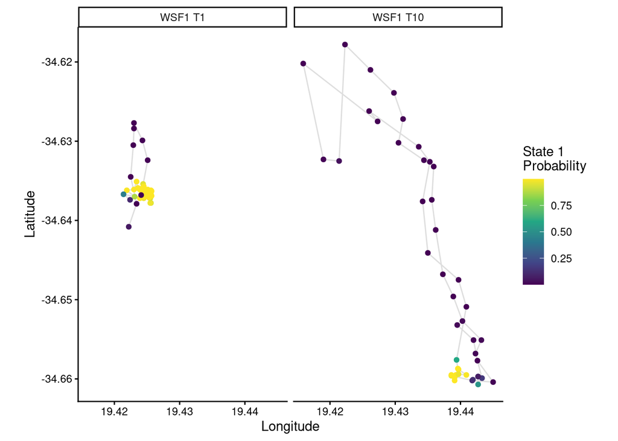

Figure 4

```r
ggplot(data = ws_HMM_rep |>
         dplyr::filter(SharksexTrackNo ==
                         c("WSF1 T1", "WSF1 T10")),
       aes(Long, Lat)) +
  geom_path(aes(group = SharksexTrackNo), alpha = .5, color = "grey") +
  geom_point(aes(color = state1prob)) +
  labs(color = "State 1 \nProbability") +
  scale_color_viridis_c(breaks = c(0, 0.25, 0.5, 0.75, 1)) +
  facet_wrap(~SharksexTrackNo) + theme_classic() +
  ylab("Latitude") + xlab("Longitude") + coord_map()
```

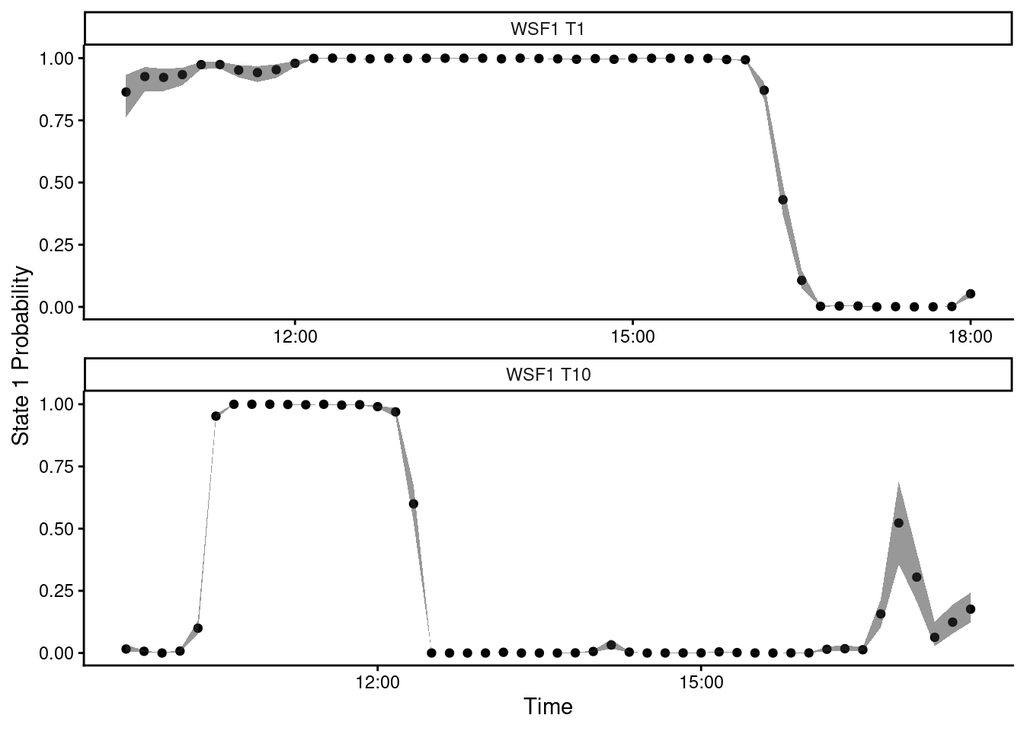

Figure 5

```r
ggplot(data = ws_HMM_rep |>
         dplyr::filter(SharksexTrackNo ==
                         c("WSF1 T1", "WSF1 T10")),
       aes(dateTime, state1prob)) + theme_classic() +
  geom_point() + geom_ribbon(aes(ymin = state1prob025,
                                 ymax = state1prob975), alpha = 0.5) +
  facet_wrap( ~ SharksexTrackNo, nrow = 2, scales = "free_x") +
  ylab("State 1 Probability") + xlab("Time")
```

Plot pseudo-residuals

```r
# plot pseudo residuals
pseudo_residuals <- fit_2stateHMM$draws(variables = "pseudo_residuals",
                                        format = "draws_matrix")
pr_mean <- colMeans(pseudo_residuals[1:1000, ])
pr_025 <- apply(pseudo_residuals[1:1000, ], 2, quantile, probs = 0.025)
pr_975 <- apply(pseudo_residuals[1:1000, ], 2, quantile, probs = 0.975)
pr_missing_index <- which(pr_mean == 0)
df <- data.frame(y = pr_mean[-pr_missing_index])
```

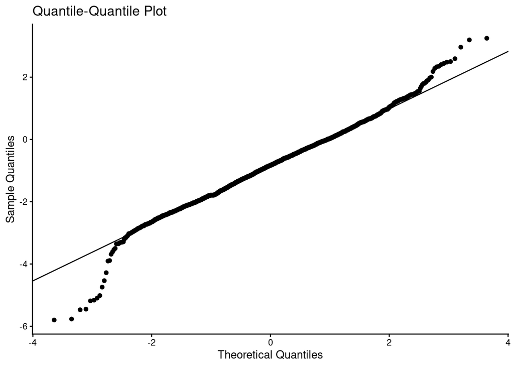

Figure 6

```r
p <- ggplot(df, aes(sample = y))
p + stat_qq() + stat_qq_line() + theme_classic() +
  xlab("Theoretical Quantiles") +
  ylab("Sample Quantiles") +
  ggtitle("Quantile-Quantile Plot")
```

Plot state decoding histograms

Simulate data from posterior predictive distribution of fitted 2-state HMM

```r
init_dist <- fit_2stateHMM$draws("initial_dist", format = "draws_array")
tpm <- fit_2stateHMM$draws("tpm", format = "draws_array")
sdd_sl_shape <- fit_2stateHMM$draws("shape", format = "draws_array")
sdd_sl_rate <- fit_2stateHMM$draws("rate", format = "draws_array")
sdd_sl_zeromass <- fit_2stateHMM$draws("mixp", format = "draws_array")
sdd_angle_loc <- fit_2stateHMM$draws("loc", format = "draws_array")
sdd_angle_conc <- fit_2stateHMM$draws("kappa", format = "draws_array")
post_state_samples <- fit_2stateHMM$draws("state_sequence", format = "draws_array")

state_samples <- matrix(NA, nrow = 4584, ncol = 1000)
state_samples[1, 1] <- sample(x = 2:1, size = 1, prob = init_dist[1,1,])
for (j in 1:1000) {
  tpm_iter <- matrix(data = tpm[j, 1, 4:1], nrow = 2)
  state_samples[1,j] <- sample(x = 2:1, size = 1, prob = init_dist[j,1,])
  for (t in 2:4584) {
    if(ws_HMM$SharksexTrackNo[t]==ws_HMM$SharksexTrackNo[t-1]) {
      state_samples[t, j] <- sample(x = 2:1,
                                    size = 1,
                                    prob = tpm_iter[state_samples[t - 1, j], ])
    } else {
      state_samples[t,j] <- sample(x = 2:1, size = 1, prob = init_dist[j, 1, ])
    }
  }
}
sim_state_counts <- apply(state_samples[1:91, ], 2, table)
sim_state_props <- sim_state_counts/91
post_state_samples_counts <- apply(post_state_samples[, 1, 1:91], 1, table)
post_state_samples_props <- post_state_samples_counts/91

ws_HMM_rep$chum <- ifelse(ws_HMM_full$CDB == "x", yes = 1, no = 0)
ws_HMM_rep$chum[which(is.na(ws_HMM_rep$CDB))] <- 0
chum_ws1_tr1 <- which(ws_HMM_rep$chum[1:91] == 1)
post_state_samples_chumcounts <- apply(post_state_samples[, 1, chum_ws1_tr1], 1, table)
post_state_samples_st2chumprops <- numeric(42)
for (j in 1:1000) {
  post_state_samples_st2chumprops[j] <-
    max(post_state_samples_chumcounts[[j]])/42
}
```

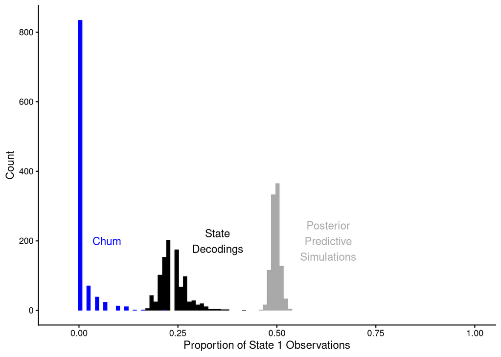

Figure 7

```r
ggplot(data = data.frame(y = sim_state_props[1, ]), aes(y)) +
  geom_histogram(bins = 100, fill = "darkgrey") + theme_classic() + xlim(-0.05, 1) +
  annotate("text", label = "Posterior\nPredictive\nSimulations", x = 0.63, y = 200, col = "darkgrey") +
  geom_histogram(data = data.frame(x = post_state_samples_props[1,]),
                 aes(x), bins = 100, fill = "black") +
  annotate("text", label="State\nDecodings", x=0.35, y=200, col="black") +
  geom_histogram(data = data.frame(p = 1 - post_state_samples_st2chumprops),
                 aes(p), bins = 100, fill = "blue") +
  annotate("text", label = "Chum", x = 0.07, y = 200, col = "blue") +
  xlab("Proportion of State 1 Observations") +
  ylab("Count")
```

# 5 2-state HMM with covariates

Time inhomogeneous HMMs with covariates in transition probability matrix time of day covariates

```r
ws_HMM$tod_cos <- cos((2*pi*(hour(ws_HMM$dateTime)*60 + minute(ws_HMM$dateTime)))/1440)
ws_HMM$tod_sin <- sin((2*pi*(hour(ws_HMM$dateTime)*60 + minute(ws_HMM$dateTime)))/1440)
```

chum covariate

```r
ws_HMM$chum <- ifelse(ws_HMM$CDB == "x", yes = 1, no = 0)
ws_HMM$chum[which(is.na(ws_HMM$CDB))] <- 0
```

sex covariate

```r
ws_HMM$sex_char <- substring(ws_HMM$SharksexTrackNo, 3, 3)
ws_HMM$sex <- ifelse(ws_HMM$sex_char == "F", yes = 0, no = 1)
HMM_covar <- matrix(data = c(rep(1, dim(ws_HMM)[1]),
                             ws_HMM$chum,
                             ws_HMM$sex,
                             ws_HMM$tod_cos,
                             ws_HMM$tod_sin), nrow = dim(ws_HMM)[1], ncol = 5)
stanHMM_2states_covariates <- list(Nstates = 2,
                                   Tlen = dim(ws_HMM)[1],
                                   track_index = as.numeric(as.factor(ws_HMM$SharksexTrackNo)),
                                   steplength = ws_HMM$steplength,
                                   angle = ws_HMM$turnang,
                                   nCovs = 4,
                                   covs = HMM_covar)
```

```r
model_2stateHMM_covariates <- cmdstan_model(
  root("sharks", "step_turn_hmm_covariates.stan")
)
fit_2stateHMM_covariates <- model_2stateHMM_covariates$sample(
  data = stanHMM_2states_covariates,
  init = init_fun_mu(2, 4),
  chains = 4
)
```

# 6 2-state HMM covariates in transition probability matrix and individual varying effects

HMM with 2 state, covariates in tpm and non-centered parametrization for varying effects

```r
stanHMM_2states_tpmcov_crencp <- list(
  Nstates = 2,
  Tlen = dim(ws_HMM)[1],
  track_index = as.numeric(as.factor(ws_HMM$SharksexTrackNo)),
  steplength = ws_HMM$steplength,
  angle = ws_HMM$turnang,
  nCovs = 4,
  covs = HMM_covar[, -1],
  Nsharks = length(unique(ws_HMM$SharksexTrackNo)),
  shark_index = as.numeric(as.factor(ws_HMM$SharksexTrackNo))
)
```

```r
model_2stateHMM_tpmcov_crencp <- cmdstan_model(
  root("sharks", "step_turn_hmm_covariates_cre_ncp.stan")
)
fit_2stateHMM_tpmcov_crencp <- model_2stateHMM_tpmcov_crencp$sample(
  data = stanHMM_2states_tpmcov_crencp,
  init = init_fun_mu(2, 1),
  chains = 1
)
```

Plot entries of transition probability matrix with covariates and individual varying effects:

```r
beta <- fit_2stateHMM_tpmcov_crencp$draws("beta", format = "draws_array")
randeff <- fit_2stateHMM_tpmcov_crencp$draws("randeff_tpm", format = "draws_array")
mu_tpm <- fit_2stateHMM_tpmcov_crencp$draws("mu_tpm", format = "draws_array")

# intercept is female, no chum
DM_female_nochum <- cbind(
  1,
  rep(0, 721),
  rep(0, 721),
  cos(2*pi*480:1200/1440),
  sin(2*pi*480:1200/1440)
)
# intercept is female, chum
DM_female_chum <- cbind(
  1,
  rep(1, 721),
  rep(0, 721),
  cos(2*pi*480:1200/1440),
  sin(2*pi*480:1200/1440)
)
DM_male_nochum <- cbind(
  1,
  rep(0, 721),
  rep(1, 721),
  cos(2*pi*480:1200/1440),
  sin(2*pi*480:1200/1440)
)
beta_array <- array(data = NA, dim = c(2, 2, length(480:1200), 100))
grid_tod <- 480:1200
track_factor <- as.factor(ws_HMM$SharksexTrackNo)
track_numeric <- as.numeric(track_factor)
```

```r
par(mfrow = c(2, 2))
for (i in 1:2) {
  for (j in 1:2) {
    beta_mat <- rbind(c(mu_tpm[1,1,1],
                        beta[1,1,c(1, 3, 5, 7)]),
                      c(mu_tpm[1,1,2],
                        beta[1,1,c(2, 4, 6, 8)]))

    tpm <- moveHMM:::trMatrix_rcpp(nbStates = 2,
                                   beta = t(beta_mat),
                                   covs = DM_male_nochum)
    plot(grid_tod, tpm[i, j, ], type = "l",
         ylim = c(0, 1), col = "grey",
         lwd = 0.5, xlab = "minute of the day",
         ylab = paste0("Pr(", i, " -> ",j, ")"))
    for (k in 2:100) {

      beta_mat <- rbind(c(mu_tpm[k,1,1],
                          beta[k,1,c(1, 3, 5, 7)]),
                        c(mu_tpm[k,1,2],
                          beta[k,1,c(2, 4, 6, 8)]))
      tpm <- moveHMM:::trMatrix_rcpp(nbStates = 2,
                                     beta = t(beta_mat),
                                     covs = DM_male_nochum)
      lines(grid_tod, tpm[i, j, ], col = "grey", lwd = .1)
    }
  }
}
beta_mat <- rbind(c(mu_tpm[1, 1, 1],
                    beta[1, 1, c(1, 3, 5, 7)]),
                  c(mu_tpm[1, 1, 2],
                    beta[1, 1, c(2, 4, 6, 8)]))
tpm <- moveHMM:::trMatrix_rcpp(nbStates = 2,
                               beta = t(beta_mat),
                               covs = DM_male_nochum)
male_chum_tpm <- data.frame(omega11 = tpm[1, 1, ],
                            omega12 = tpm[1, 2, ],
                            omega21 = tpm[2, 1, ],
                            omega22 = tpm[2, 2, ],
                            dateTime = 480:1200,
                            draw = 1)
for (k in 2:500) {
  beta_mat <- rbind(c(mu_tpm[k, 1, 1],
                      beta[k, 1, c(1, 3, 5, 7)]),
                    c(mu_tpm[k, 1, 2],
                      beta[k, 1, c(2, 4, 6, 8)]))
  tpm <- moveHMM:::trMatrix_rcpp(nbStates = 2,
                                 beta = t(beta_mat),
                                 covs = DM_male_nochum)
  male_chum_tpm <- rbind(male_chum_tpm,
                         data.frame(omega11 = tpm[1, 1, ],
                                    omega12 = tpm[1, 2, ],
                                    omega21 = tpm[2, 1, ],
                                    omega22 = tpm[2, 2, ],
                                    dateTime = 480:1200,
                                    draw = k))
}
colnames(male_chum_tpm)[1] <- "omega[11](t)"
colnames(male_chum_tpm)[2] <- "omega[12](t)"
colnames(male_chum_tpm)[3] <- "omega[21](t)"
colnames(male_chum_tpm)[4] <- "omega[22](t)"
male_chum_tpm_long <- male_chum_tpm |>
  pivot_longer(!c(dateTime, draw), names_to = "omega")
p1 <- ggplot(male_chum_tpm_long, aes(dateTime, value)) +
  geom_line(aes(group = draw), alpha = 0.1, col = "darkgrey") +
  facet_wrap(~omega, nrow = 2, ncol = 2, labeller = label_parsed) +
  theme_classic() + ylab("Probability") +
  xlab("Time") +
  scale_x_continuous(breaks = c(540, 720, 900, 1080),
                     labels = c("09:00", "12:00", "15:00", "18:00")) +
  ggtitle("Male white shark, no chum")

par(mfrow = c(2, 2))
for (i in 1:2) {
  for (j in 1:2) {

    beta_mat <- rbind(c(mu_tpm[1, 1, 1],
                        beta[1, 1, c(1, 3, 5, 7)]),
                      c(mu_tpm[1, 1, 1],
                        beta[1, 1, c(2, 4, 6, 8)]))

    tpm <- moveHMM:::trMatrix_rcpp(nbStates = 2,
                                   beta = t(beta_mat),
                                   covs = DM_female_nochum)

    plot(grid_tod, tpm[i, j, ], type = "l",
         ylim = c(0, 1), col = "grey",
         lwd = 0.5, xlab = "minute of the day",
         ylab = paste0("Pr(", i, " -> ",j, ")"))

    for (k in 2:100) {

      beta_mat <- rbind(c(mu_tpm[k, 1, 1],
                          beta[k, 1, c(1, 3, 5, 7)]),
                        c(mu_tpm[k, 1, 2],
                          beta[k, 1, c(2, 4, 6, 8)]))

      tpm <- moveHMM:::trMatrix_rcpp(nbStates = 2,
                                     beta = t(beta_mat),
                                     covs = DM_female_nochum)
      lines(grid_tod, tpm[i, j, ], col = "grey", lwd = .1)
    }
  }
}

beta_mat <- rbind(c(mu_tpm[1, 1, 1],
                    beta[1, 1, c(1, 3, 5, 7)]),
                  c(mu_tpm[1, 1, 2],
                    beta[1, 1, c(2, 4, 6, 8)]))
tpm <- moveHMM:::trMatrix_rcpp(nbStates = 2,
                               beta = t(beta_mat),
                               covs = DM_male_nochum)
female_chum_tpm <- data.frame(
  omega11 = tpm[1, 1, ],
  omega12 = tpm[1, 2, ],
  omega21 = tpm[2, 1, ],
  omega22 = tpm[2, 2, ],
  dateTime = 480:1200,
  draw = 1
)
for (k in 2:500) {
  beta_mat <- rbind(c(mu_tpm[1, 1, 1],
                      beta[k, 1, c(1, 3, 5, 7)]),
                    c(mu_tpm[1, 1, 2],
                      beta[k, 1, c(2, 4, 6, 8)]))
  tpm <- moveHMM:::trMatrix_rcpp(nbStates = 2,
                                 beta = t(beta_mat),
                                 covs = DM_female_nochum)
  female_chum_tpm <- rbind(
    female_chum_tpm,
    data.frame(omega11 = tpm[1, 1, ],
               omega12 = tpm[1, 2, ],
               omega21 = tpm[2, 1, ],
               omega22 = tpm[2, 2, ],
               dateTime = 480:1200,
               draw = k)
  )
}

colnames(female_chum_tpm)[1] <- "omega[11](t)"
colnames(female_chum_tpm)[2] <- "omega[12](t)"
colnames(female_chum_tpm)[3] <- "omega[21](t)"
colnames(female_chum_tpm)[4] <- "omega[22](t)"
female_chum_tpm_long <- female_chum_tpm |>
  pivot_longer(!c(dateTime, draw), names_to = "omega")
p2 <- ggplot(female_chum_tpm_long, aes(dateTime, value)) +
  geom_line(aes(group = draw), alpha = 0.1, col = "darkgrey") +
  facet_wrap(~omega, nrow = 2, ncol = 2, labeller = label_parsed) +
  theme_classic() + ylab("Probability") +
  xlab("Time") +
  scale_x_continuous(breaks = c(540, 720, 900, 1080),
                     labels = c("09:00", "12:00", "15:00", "18:00")) +
  ggtitle("Female white shark, no chum")

wsf1_t1 <- which(ws_HMM$SharksexTrackNo == "WSF1 T1")
wsf1_t1_covar <- HMM_covar[wsf1_t1,]
wsf1_dateTime <- 60*hour(ws_HMM$dateTime[seq_along(wsf1_t1)]) +
  minute(ws_HMM$dateTime[seq_along(wsf1_t1)])
dim(HMM_covar)
```

```
[1] 4584    5
```

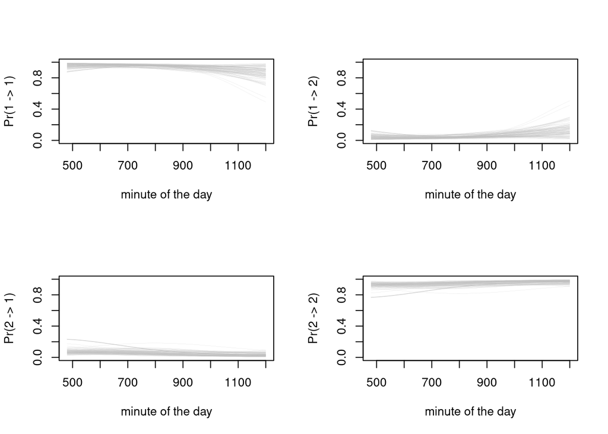

Figure 8

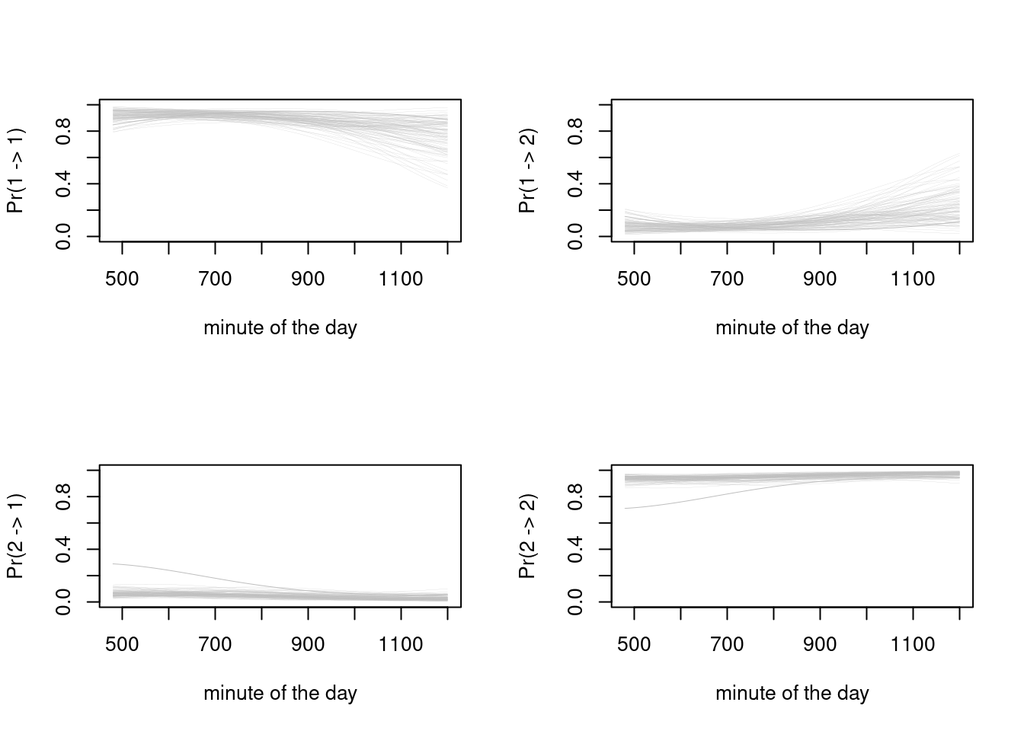

Figure 9

```r
beta_mat <- rbind(c(randeff[1, 1, 1],
                    beta[1, 1, c(1, 3, 5, 7)]),
                  c(randeff[1, 1, 2],
                    beta[1, 1, c(2, 4, 6, 8)]))
tpm <- moveHMM:::trMatrix_rcpp(nbStates = 2,
                               beta = t(beta_mat),
                               covs = wsf1_t1_covar)
wsf1_chum_tpm <- data.frame(
  omega11 = tpm[1, 1, ],
  omega12 = tpm[1, 2, ],
  omega21 = tpm[2, 1, ],
  omega22 = tpm[2, 2, ],
  dateTime = 60*hour(ws_HMM$dateTime[seq_along(wsf1_t1)]) +
    minute(ws_HMM$dateTime[seq_along(wsf1_t1)]),
  draw = 1
)
for (k in 2:500) {
  beta_mat <- rbind(c(mu_tpm[k, 1, 1],
                      beta[k, 1, c(1, 3, 5, 7)]),
                    c(mu_tpm[k, 1, 2],
                      beta[k, 1, c(2, 4, 6, 8)]))
  tpm <- moveHMM:::trMatrix_rcpp(nbStates = 2,
                                 beta = t(beta_mat),
                                 covs = wsf1_t1_covar)
  wsf1_chum_tpm <- rbind(
    wsf1_chum_tpm,
    data.frame(
      omega11 = tpm[1, 1, ],
      omega12 = tpm[1, 2, ],
      omega21 = tpm[2, 1, ],
      omega22 = tpm[2, 2, ],
      dateTime = 60*hour(ws_HMM$dateTime[seq_along(wsf1_t1)]) +
        minute(ws_HMM$dateTime[seq_along(wsf1_t1)]),
      draw = k
    )
  )
}
colnames(wsf1_chum_tpm)[1] <- "omega[11](t)"
colnames(wsf1_chum_tpm)[2] <- "omega[12](t)"
colnames(wsf1_chum_tpm)[3] <- "omega[21](t)"
colnames(wsf1_chum_tpm)[4] <- "omega[22](t)"
wsf1_chum <- which(HMM_covar[wsf1_t1, 2] ==1)
wsf1_chum_tpm_long <- wsf1_chum_tpm |>
  pivot_longer(!c(dateTime, draw), names_to = "omega")

p3 <- ggplot(wsf1_chum_tpm_long, aes(dateTime, value)) +
  geom_line(aes(group = draw),
            alpha = 0.1, col = "darkgrey") +
  geom_vline(xintercept = wsf1_dateTime[wsf1_chum],
             linetype = 1, col = "lightgrey", alpha = 0.15) +
  facet_wrap(~omega, nrow = 2, ncol = 2, labeller = label_parsed) +
  theme_classic() + ylab("Probability") +
  xlab("Time") +
  scale_x_continuous(breaks = c(540, 720, 900, 1080),
                     labels = c("09:00", "12:00", "15:00", "18:00")) +
  ggtitle("White shark female 1, track 1")
```

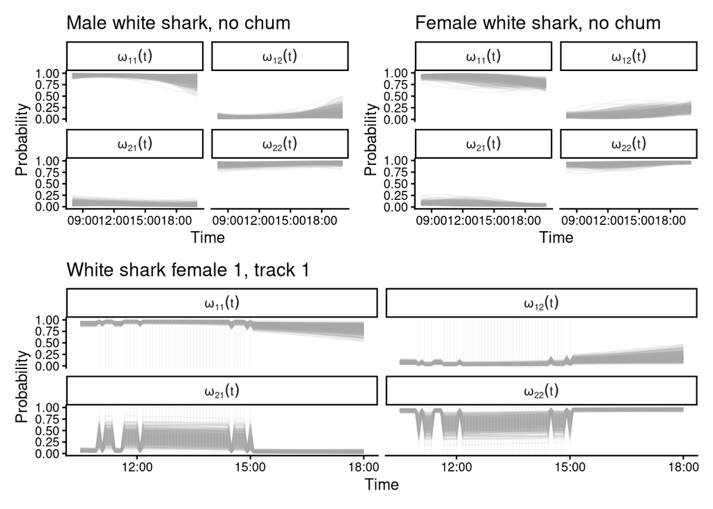

Figure 10

```r
(p1 + p2)/p3
```

# References

Towner, A. V., V. Leos-Barajas, R. Langrock, R. S. Schick, M. J. Smale, T. Kaschke, O. J. D. Jewell, and Y. P. Papastamatiou. 2016. “Sex-Specific and Individual Preferences for Hunting Strategies in White Sharks.” *Functional Ecology* 30: 1397–407.

# Licenses

- Code © 2025, Vianey Leos Barajas, licensed under BSD-3.
- Text © 2025, Vianey Leos Barajas, licensed under CC-BY-NC 4.0.